# Newsvendor notes

Me

2024-09-04

**THESE NOTES ARE A WORK IN PROGRESS AND UPDATES TO COME**

Assigned paper:

Dana Jr, J. D., & Petruzzi, N. C. (2001). Note: The newsvendor model with endogenous demand. Management Science, 47(11), 1488-1497. https://doi.org/10.1287/mnsc.47.11.1488.10252

## Some unofficial background resources for newsvendor

Metrics for choosing a resource here: (1) I was able to pay attention to it easily enough, & (2) I felt I learned something about newsvendor.

Not metrics for choosing a resource here: (1) rigor, (2) Completeness, etc…

- 4 part intro series by Piyush Shah (less than 21 minutes total)
  - https://youtube.com/playlist?list=PLsJeWWZGL5VRKmaCStdjO9xnXInS_5JwH&si=eYGSN9SA14thuvoN

## More official background resources for newsvendor

- A review of literature on single-period newsvendor
  - Khouja, M. 1999. The single-period (news-vendor) problem: Literature review and suggestions for future research. Omega 27 537–553. https://doi.org/10.1016/S0305-0483(99)00017-1

## Classic newsvendor model

If you sell perishable goods, how much should you order per day? You lose money if you order more than the day’s demand because the items are perishable. You lose money if you order fewer goods than demand because you’ve lost potential sales. How do you find the **Optimal Order Quantity**???

Parameters needed:

- $D$ - Demand uncertainty (distribution)
- $C$ - Unit cost - cost for newsvendor to buy each unit from supplier
- $P$ - Unit selling price - cost for customer to buy each unit from newsvendor
- $S$ - Unit salvage - can represent *either*
  - Per unit value to sell excess inventory at perhaps a discounted rate
  - Per unit cost to dispose of excess inventory

**Optimal Order Quantity (**$Q^*$):

$$Q^* = F^{-1}(\frac{Cu}{Cu + Co})$$

- $F^{-1}$ is the inverse CDF of $D$
  - $D$ - Demand - typically modeled as random variable with known distribution (normal, poisson, etc… informed by context+historical data)
  - Remember inverse CDF is like going from $p$ value to $\text{critical value}$

```r
# e.g. from hypothesis testing we use the inverse normal cdf
qnorm(0.05)
```

```
## [1] -1.644854
```

```r
qnorm(0.95)
```

```
## [1] 1.644854
```

- $\frac{Cu}{Cu + Co}$ - the “critical ratio”
  - Intuition
    - Shows relationship between overage cost and underage cost on [0, 1]
      - When $Cu < Co \to \text{critical ratio} < 0.5$
      - When $Cu = Co \to \text{critical ratio} = 0.5$
      - When $Cu > Co \to \text{critical ratio} > 0.5$
    - **We like the [0,1] range as this will map to the distribution of demand to inform optimal order quantity. We will find** $Q^*$ **where the area under the demand distribution is equal to the** $\text{critical ratio}$ **(using demand curve’s inverse CDF)**
  - $Co = C - S$ - unit overage cost
    - How much money do we lose by having too much inventory?
    - Is a function of how much you originally paid per unit $C$ and subtract how much you can resell for $S$ (aka salvage). Note if $S < 0$ this is incurring additional cost of disposal
  - $Cu = P - C$ - unit underage cost
    - How much money do we lose by having to little inventory? (opportunity cost)
    - Really just a formula for profit per unit, but think of as a loss since it’s a sale we could’ve made given enough inventory.
    - NOTE: some formulations include the value of a “loss of good will”; meaning not only did we lose a sale, but a repeated stock-out event can lose customers: $Cu = (P-C) + \text{Loss of Goodwill}$

### Worked example

Example for normal demand.

```r
# Example for normal demand

# Demand distribution params (normal in this case)
demand_mean <- 100
demand_sd <- 10

# Cost params
unit_cost <- 10
unit_price <- 15
unit_salvage <- 2
```

```r
# Calculate overage and underage
(Cu <- unit_price - unit_cost)
```

```
## [1] 5
```

```r
(Co <- unit_cost - unit_salvage)
```

```
## [1] 8
```

```r
# Calculate critical ratio
(critical_ratio <- Cu / (Cu + Co))
```

```
## [1] 0.3846154
```

```r
# Calculate Q*
(q_star <- qnorm(critical_ratio, mean = demand_mean, sd = demand_sd))
```

```
## [1] 97.06619
```

That case visualized on the demand distribution:

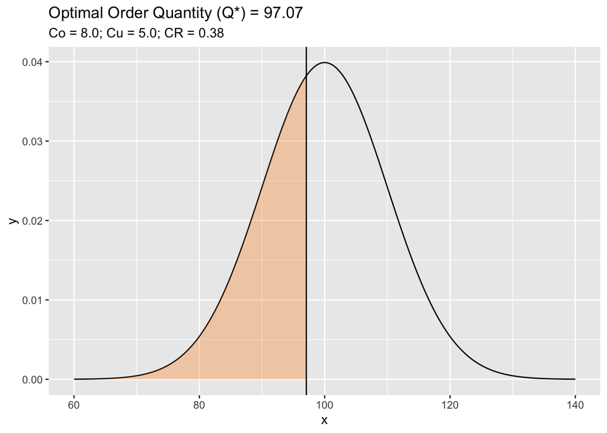

```r
plot_normal_newsvendor(
  demand_mean = 100,
  demand_sd = 10,
  unit_cost = 10,
  unit_price = 15,
  unit_salvage = 2
)
```

A case where $Cu$ >> $Co$.

Any sale is too valuable to miss, stock for highest cases of demand.

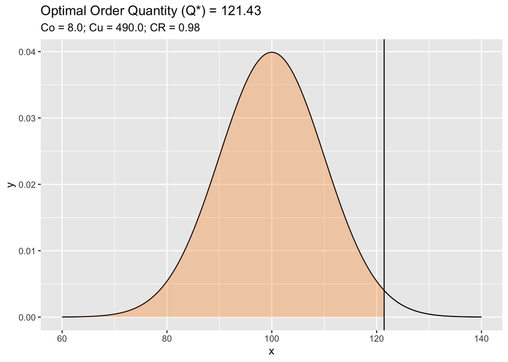

```r
plot_normal_newsvendor(
  demand_mean = 100,
  demand_sd = 10,
  unit_cost = 10,
  unit_price = 500,
  unit_salvage = 2
)
```

A case where $Cu$ << $Co$.

Having more inventory than demand is very costly, prioritize having no leftovers.

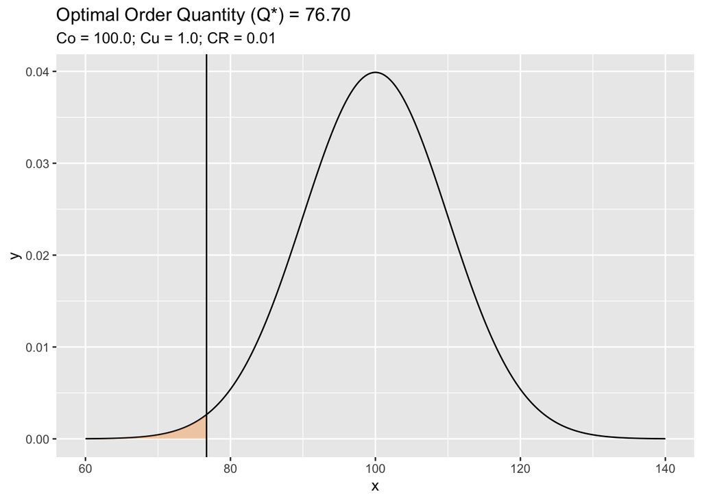

```r
plot_normal_newsvendor(
  demand_mean = 100,
  demand_sd = 10,
  unit_cost = 100,
  unit_price = 101,
  unit_salvage = 0
)
```